# Scalar on Function Regression with Physical Activity Data

Adpapted from ‘Functional Data Analysis with R’ by Crainiceanu, Goldsmith, Leroux & Cui

Lily Koffman

UVA School of Data Science

## Introduction: accelerometry data

[figure not shown]

## Introduction: accelerometry data

[figure not shown]

## We can get physical activity measures from accelerometers

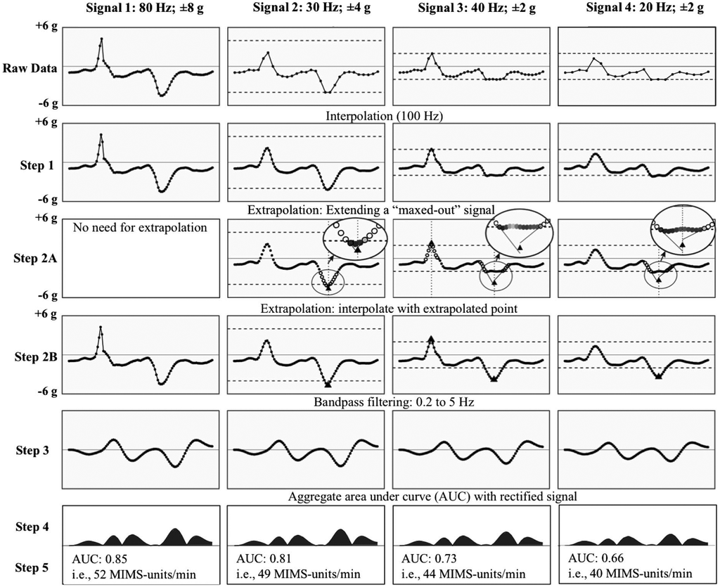

Calculating Monitor Independent Movement Summaries (MIMS)

doi: 10.1123/jmpb.2018-0068

## We can measure physical activity in big studies

[figure not shown]

## What questions might we want to answer?

## What questions might we want to answer?

What is the relationship between physical activity and BMI<sup>1</sup>?

[^1]: Acknowledging problematic aspects of BMI, it’s a nice continuous outcome for us to model

### Data

How can we model this? Here’s what our data looks like

```r
mims_sl |>
  select(SEQN, age, gender, bmi, starts_with("min"))
```

```
# A tibble: 8,571 × 1,444
   SEQN    age gender   bmi min_0001 min_0002 min_0003 min_0004 min_0005
   <chr> <dbl> <fct>  <dbl>    <dbl>    <dbl>    <dbl>    <dbl>    <dbl>
 1 62161    22 Male    23.3    1.11    3.12     1.47      0.938   1.60
 2 62164    44 Female  23.2    1.92    1.67     2.38      0.935   2.59
 3 62169    21 Male    20.1    5.85    5.18     4.76      6.48    6.85
 4 62174    80 Male    33.9    5.42    3.48     3.72      3.81    6.85
 5 62177    51 Male    20.1    6.14    8.06     9.99      6.60    4.57
 6 62178    80 Male    28.5    0.167   0.429    0.131     1.20    0.0796
 7 62180    35 Male    27.9    0.039   0        0         0       0.369
 8 62184    26 Male    22.1    1.55    2.81     3.86      4.76    6.10
 9 62189    30 Female  22.4    2.81    0.195    0.163     0       0.145
10 62199    57 Male    28      0.031   0.0359   0.0387    0.079   0.109
# ℹ 8,561 more rows
# ℹ 1,435 more variables: min_0006 <dbl>, min_0007 <dbl>, min_0008 <dbl>,
#   min_0009 <dbl>, min_0010 <dbl>, min_0011 <dbl>, min_0012 <dbl>,
#   min_0013 <dbl>, min_0014 <dbl>, min_0015 <dbl>, min_0016 <dbl>,
#   min_0017 <dbl>, min_0018 <dbl>, min_0019 <dbl>, min_0020 <dbl>,
#   min_0021 <dbl>, min_0022 <dbl>, min_0023 <dbl>, min_0024 <dbl>,
#   min_0025 <dbl>, min_0026 <dbl>, min_0027 <dbl>, min_0028 <dbl>, …
```

### Data

How can we model this? Here’s what our data looks like

```r
df_tf = mims_sl %>%
  mutate(
    activity = tfd(as.matrix(select(., starts_with("min_"))), arg = seq(1/60, 24, length = 1440))) %>%
  select(SEQN, age, gender, bmi, activity)

df_tf
```

```
# A tibble: 8,571 × 5
   SEQN    age gender   bmi                   activity
   <chr> <dbl> <fct>  <dbl>                  <tfd_reg>
 1 62161    22 Male    23.3 ▁▁▁▁▁▁▂▂▄▄▄▄▄▄▄▃▄▃▃▃▃▂▂▁▁▁
 2 62164    44 Female  23.2 ▁▁▁▁▁▁▂▃▃▃▃▃▃▃▃▃▄▃▃▄▂▂▂▃▂▁
 3 62169    21 Male    20.1 ▂▂▁▁▁▁▁▁▁▂▁▂▂▂▃▂▃▂▃▂▃▃▂▃▂▂
 4 62174    80 Male    33.9 ▁▁▁▁▁▁▁▁▁▂▃▂▂▂▂▂▂▂▃▂▂▂▂▂▂▂
 5 62177    51 Male    20.1 ▁▁▁▁▁▁▁▂▃▂▂▃▃▃▃▃▂▃▃▃▂▃▃▃▂▃
 6 62178    80 Male    28.5 ▁▁▁▁▁▁▁▂▃▂▃▂▂▂▂▂▂▂▂▂▂▂▂▁▁▁
 7 62180    35 Male    27.9 ▁▁▁▁▁▁▁▁▅▄▃▄▃▃▃▃▃▄▄▅▄▃▃▂▃▁
 8 62184    26 Male    22.1 ▁▁▁▁▁▁▃▃▃▃▄▄▃▃▃▃▃▃▃▃▃▃▃▂▂▁
 9 62189    30 Female  22.4 ▁▁▁▁▁▁▂▄▄▄▄▄▄▄▄▄▄▅▅▆▄▄▄▄▃▁
10 62199    57 Male    28   ▁▁▁▁▁▁▁▃▃▄▄▄▄▄▄▄▄▄▃▄▃▃▂▃▂▁
# ℹ 8,561 more rows
```

### Data

How can we model this? Here’s what our data looks like

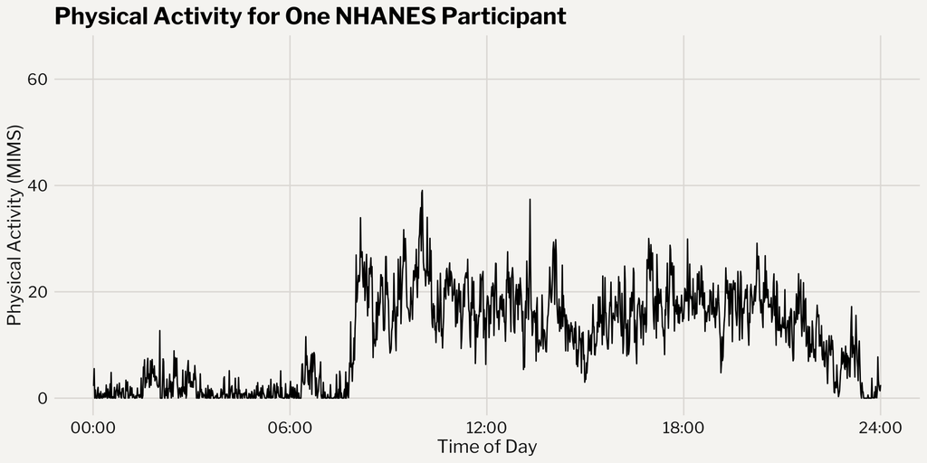

### Data

How can we model this? Here’s what our data looks like

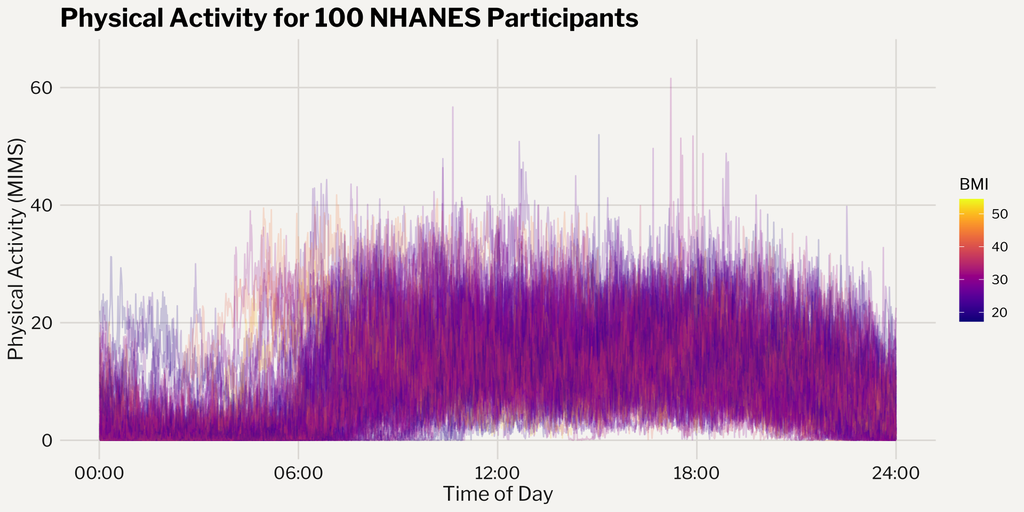

### Take the mean?

```r
mims_mean =
  mims_sl |>
  pivot_longer(cols = starts_with("min")) |>
  group_by(SEQN, age, gender, bmi) |>
  summarize(mean_mims = mean(value, na.rm = TRUE), .groups = "drop")

mims_mean
```

```
# A tibble: 8,571 × 5
   SEQN    age gender   bmi mean_mims
   <chr> <dbl> <fct>  <dbl>     <dbl>
 1 62161    22 Male    23.3      9.16
 2 62164    44 Female  23.2      9.31
 3 62169    21 Male    20.1      6.96
 4 62174    80 Male    33.9      5.96
 5 62177    51 Male    20.1      8.28
 6 62178    80 Male    28.5      5.20
 7 62180    35 Male    27.9      9.86
 8 62184    26 Male    22.1      9.45
 9 62189    30 Female  22.4     12.9
10 62199    57 Male    28       10.1
# ℹ 8,561 more rows
```

### Take the mean?

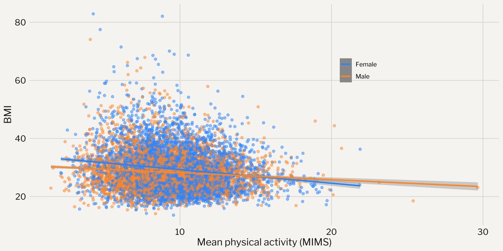

### Take the mean?

$$\text{BMI}_i = \beta_0 + \beta_1\overline{\text{MIMS}}_i + \beta_2\text{age}_i + \beta_3\text{gender}_i + \epsilon_i$$

```r
lin_mod = lm(bmi ~ mean_mims + age + gender, data = mims_mean)

stargazer(lin_mod, type = "text", ci = TRUE, report = c("vcs*"), single.row = TRUE)
```

```
===============================================
                        Dependent variable:
                    ---------------------------
                                bmi
-----------------------------------------------
mean_mims           -0.336 (-0.395, -0.278)***
age                   0.007 (-0.001, 0.016)*
genderMale          -1.180 (-1.476, -0.883)***
Constant            32.331 (31.485, 33.177)***
-----------------------------------------------
Observations                   8,571
R2                             0.024
Adjusted R2                    0.024
Residual Std. Error      6.961 (df = 8567)
F Statistic          70.021*** (df = 3; 8567)
===============================================
Note:               *p<0.1; **p<0.05; ***p<0.01
```

### Problem? Information loss

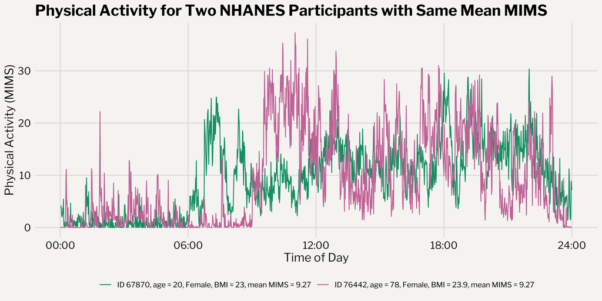

### What about binning?

```r
mims_binned =
  df_tf |>
  mutate(
    mims_binned = tf_smooth(
      activity,
      method = "rollmean",
      k = 120,
      align = "center",
      fill = "extend"
    ),
    mims_binned = tfd(mims_binned, arg = seq(1, 23, by = 2))
  ) |>
  select(SEQN, age, gender, bmi, mims_binned)
```

### What about binning?

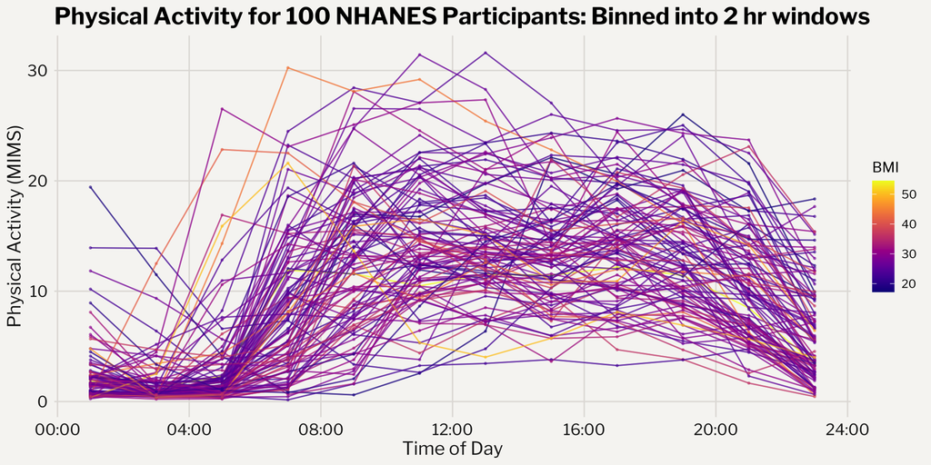

### Regression in each bin?

$$\begin{align}
\text{BMI}_i=& \beta_0 + \beta_1\text{MIMS bin1}_i +
\beta_{2}\text{age}_i + \beta_{3}\text{gender}_i + \epsilon_i \\
\text{BMI}_i=& \beta_0 + \beta_1\text{MIMS bin2}_i +
\beta_{2}\text{age}_i + \beta_{3}\text{gender}_i + \epsilon_i \\
... &\\
\text{BMI}_i=& \beta_0 + \beta_1\text{MIMS bin12}_i +
\beta_{2}\text{age}_i + \beta_{3}\text{gender}_i + \epsilon_i \\
\end{align}$$

```r
fit_binned =
  lm(bmi ~ .,
     data = tf_spread(mims_binned |> select(-SEQN)))
```

### Regression in each bin?

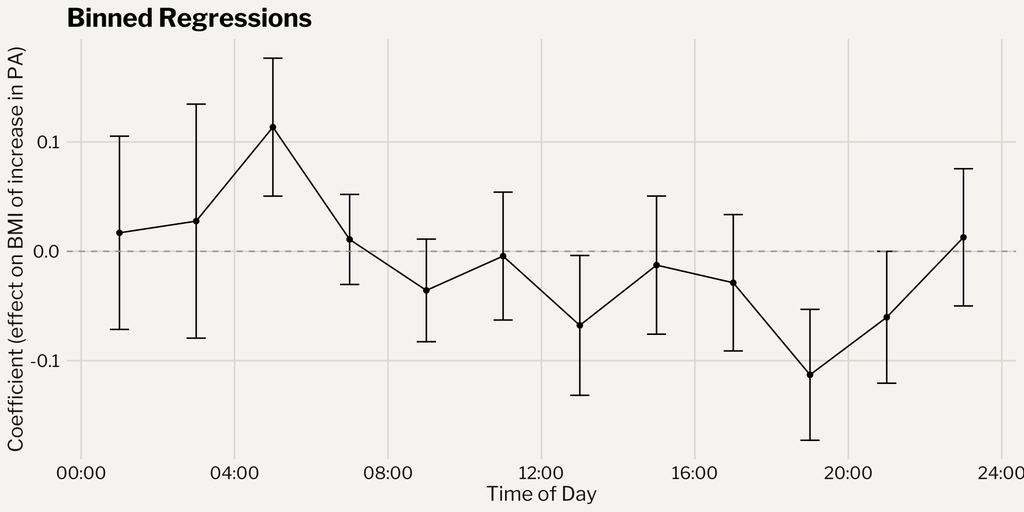

### Problems with binning

- Bin size arbitrary
- As bins become smaller, coefficients over time become more different, but it’s unclear if this is due to signal or noise
- Solution: **scalar on function regression** (SoFR)
- We treat the physical activity predictor as a **smooth function over time**
- Let’s do some math to make this connection

### Binning –> SoFR connection

Define:

$X_i(s_j)$: MIMS value at time $s_j$ for person $i$

$\bar{X}_{ib}$: Average MIMS in bin $b$ for person $i$

$\beta_b$: regression coefficient for bin $b$ in the previous model

### Binning –> SoFR connection

Define:

**$X_i(s_j)$: MIMS value at time $s_j$ for person $i$**

$\bar{X}_{ib}$: Average MIMS in bin $b$ for person $i$

$\beta_b$: regression coefficient for bin $b$ in the previous model

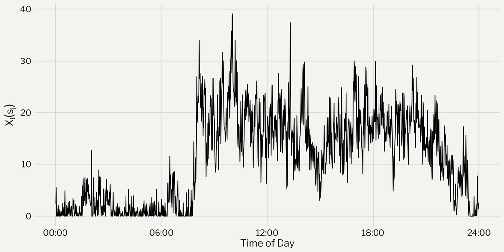

### Binning –> SoFR connection

Define:

$X_i(s_j)$: MIMS value at time $s_j$ for person $i$

**$\bar{X}_{ib}$: Average MIMS in bin $b$ for person $i$**

$\beta_b$: regression coefficient for bin $b$ in the previous model

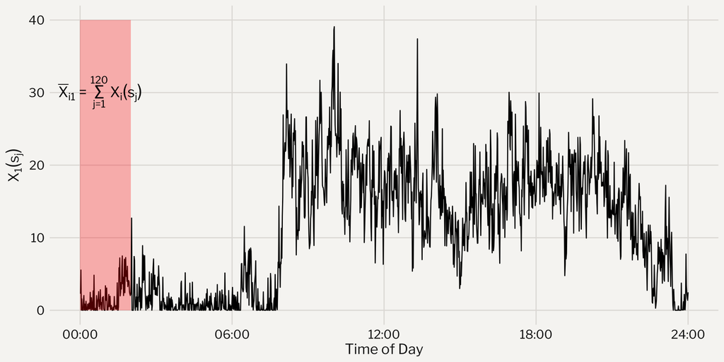

### Binning –> SoFR connection

Define:

$X_i(s_j)$: MIMS value at time $s_j$ for person $i$

$\bar{X}_{ib}$: Average MIMS in bin $b$ for person $i$

**$\beta_b$: regression coefficient for bin $b$ in the previous model**

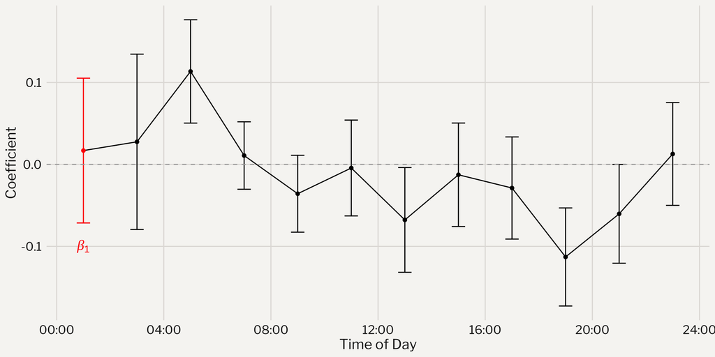

### Binning –> SoFR connection

$$\begin{aligned}
\beta_1\bar{X}_{i1} &= \beta_1\frac{1}{120}\sum_{j=1}^{120}X_i(s_j) \\
&= \frac{\beta_1}{2}\Big[\frac{1}{60}\sum_{j=1}^{120}X_i(s_j)\Big] \\
&\approx \int_0^2\frac{\beta_1}{2}X_i(s)\,ds
\end{aligned}$$
Last step: numeric approximation to true integral; emphasizing that $X_i(s_j)$ is a continuous function observed discretely

### Binning –> SoFR connection

We could formalize this, defining function $\beta^{\text{step}}(s)$ as:

$$\beta^{\text{step}}(s) = \begin{cases} \frac{\beta_1}{2}, 0 < s \leq 2\\
\frac{\beta_2}{2}, 2 < s \leq 4\\
\dots \\
\frac{\beta_{12}}{2}, 22 < s \leq 24\\
\end{cases}$$

In words: $\beta^{\text{step}}(s)$ is a step function with step heights equal to half of the bin coefficients

### Binning –> SoFR connection

We can express the model using bin averages as a function of $\beta^{\text{step}}(s)$:

$$\sum_{b=1}^{12}\beta_b\bar{X}_{ib} \approx \int_0^{24}\beta^{\text{step}}(s)X_i(s)\,ds$$

### Binning –> SoFR connection

We can then plot these bin coefficients:

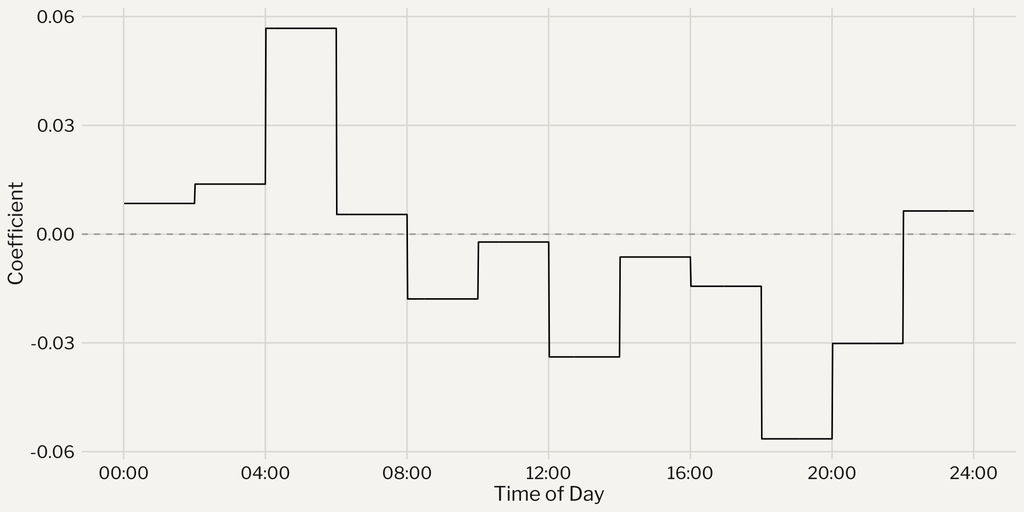

### What have we learned?

We can obtain identical predicted BMI in two ways

1. Take average of predictors in each bin, regress BMI on these averages
2. Integrate the product of the predictors (not binned) and the coefficient step function

### What have we learned?

We can obtain identical predicted BMI in two ways

**1. Take average of predictors in each bin, regress BMI on these averages**

2. Integrate the product of the predictors (not binned) and the coefficient step function

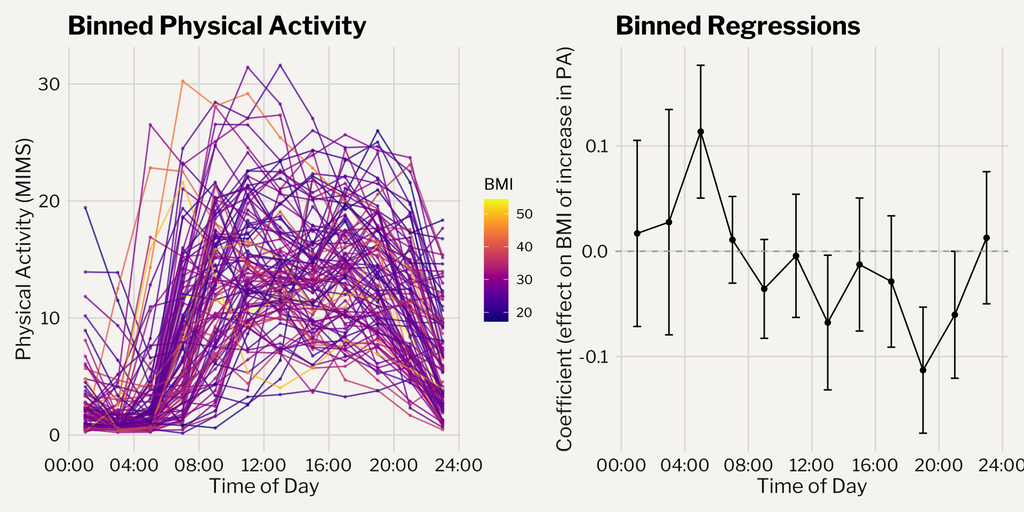

### What have we learned?

We can obtain identical predicted BMI in two ways

1. Take average of predictors in each bin, regress BMI on these averages

**2. Integrate the product of the predictors (not binned) and the coefficient step function**

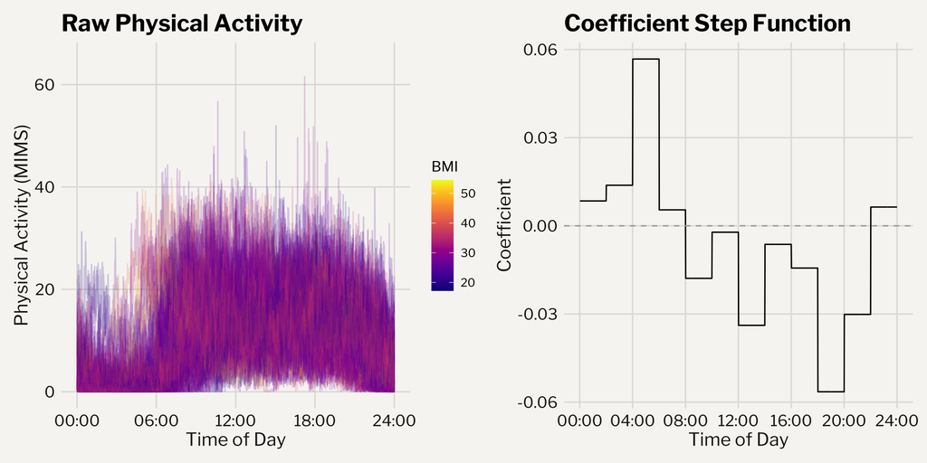

### Simple linear scalar on function regression

We will extend the step coefficient approach to a more general functional coefficient

$$Y_i = \beta_0 + \int_S\beta_1(s) X_i(s)ds + \epsilon_i$$

Earlier, we required $\beta_1(s)$ to be a step function approximated by a regression model based on bin averages, now $\beta_1(s)$ is more flexible

### Simple linear scalar on function regression

We will extend the step coefficient approach to a more general functional coefficient

$$Y_i = \beta_0 + \int_S\beta_1(s) X_i(s)ds + \epsilon_i$$

Earlier, we required $\beta_1(s)$ to be a step function approximated by a regression model based on bin averages, now $\beta_1(s)$ is more flexible

Interpretation is the same: $\beta_1(s)$: weight of predictor function at each $s\in S$, product of $X_i(s)$ and $\beta_1(s)$ is integrated over $S$ to get the total contribution to the outcome of the functional term

### Simple linear scalar on function regression

We will extend the step coefficient approach to a more general functional coefficient

$$Y_i = \beta_0 + \int_S\beta_1(s) X_i(s)ds + \epsilon_i$$

Earlier, we required $\beta_1(s)$ to be a step function approximated by a regression model based on bin averages, now $\beta_1(s)$ is more flexible

Interpretation is the same: $\beta_1(s)$: weight of predictor function at each $s\in S$, product of $X_i(s)$ and $\beta_1(s)$ is integrated over $S$ to get the total contribution to the outcome of the functional term

$\beta_1(s)$: effect on outcome of one unit increase in $X_i(s)$ when all other values of $X_i(s'), s'\neq s$ are held constant (kind of awkward!)

### Simple linear scalar on function regression visualized

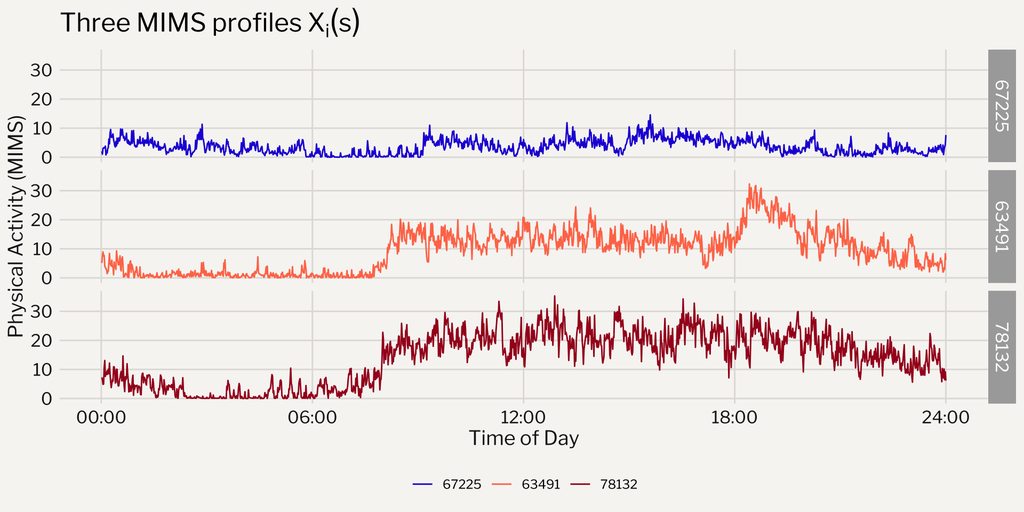

### Simple linear scalar on function regression visualized

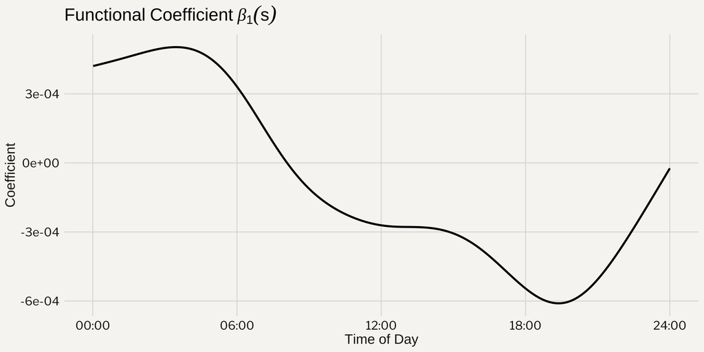

### Simple linear scalar on function regression visualized

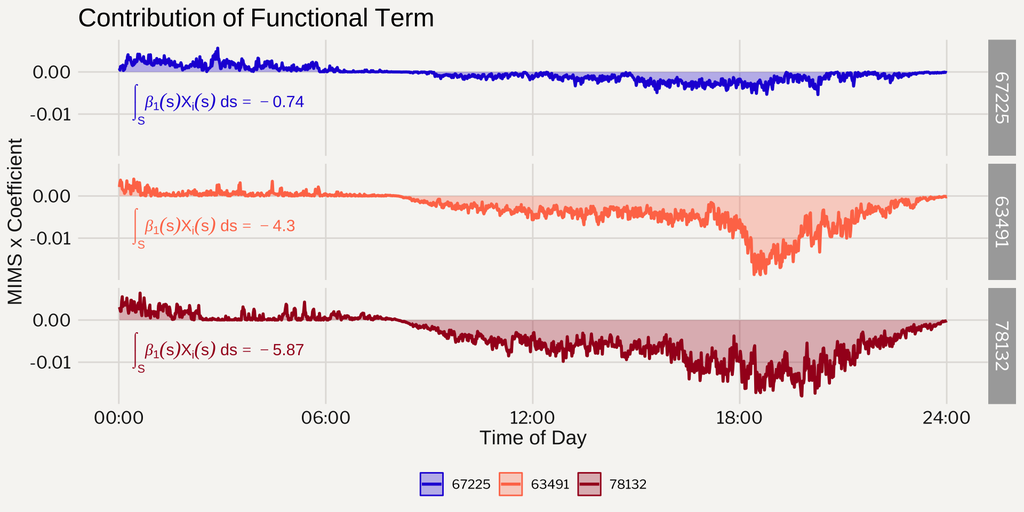

### Simple linear scalar on function regression visualized

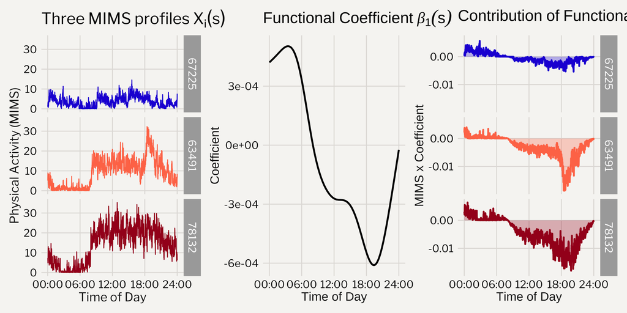

### Estimation

How do we actually estimate $\beta_1(s)$?

### Estimation

How do we actually estimate $\beta_1(s)$?

Need to minimize:

$$\min_{\beta_0, \beta_1(s)}\sum_{i=1}^n\Big\{Y_i - \beta_0 - \int_S\beta_1(s)X_i(s)\,ds\Big\}^2$$
How can we do this?

### Parametric estimation

**Basic idea**: expand coefficient using a basis expansion, which allows us to reframe problem as one of multiple linear regression

This involves some math

### Parametric estimation

Expand coefficient function using a low dimensional basis expansion

$$\beta_1(s) = \sum_{k=1}^K \beta_{1k}B_k(s)$$

Collection of basis functions: $B_1(s), \dots, B_K(s)$

### Parametric estimation

What are these $B_k$?

One example: simple quadratic basis

$$\begin{cases} B_1(s) = 1 \\
B_2(s) = s \\
B_3(s) = s^2
\end{cases}$$

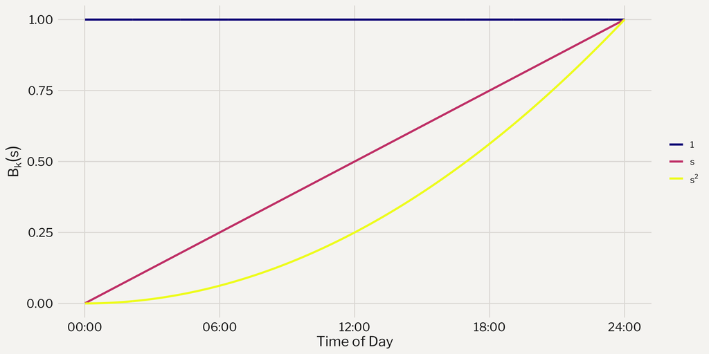

### Parametric estimation

Another example: cubic B-spline basis with 8 degrees of freedom

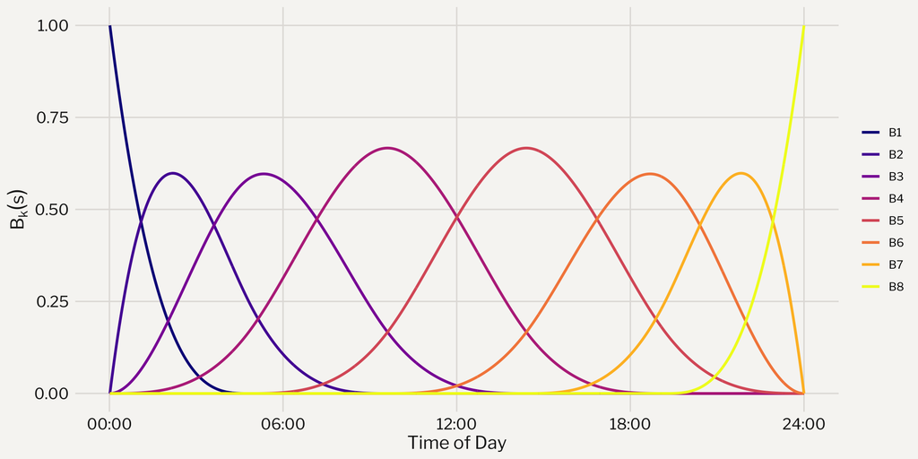

### Parametric estimation

Let’s plug in the basis expansion to our integral:

$$\begin{aligned}
E(Y_i) &= \beta_0 + \int_S \beta_1(s)X_i(s)\,ds\\
&= \beta_0 + \sum_{k=1}^K\big[\int_SB_k(s)X_i(s)\,ds\big]\beta_{1k}\\
&= \beta_0 + \mathbf{C}_i^t\boldsymbol{\beta}_1
\end{aligned}$$

### Parametric estimation

**Key insight**:

Let $C_{ik} = \int_SB_k(s)X_i(s)ds$, $\mathbf{C}_i = \big[C_{i1}, C_{i2}, \dots, C_{iK}\big]$, and $\boldsymbol{\beta}_1 = (\beta_{11}, \dots, \beta_{1K})^t$ be the vector of basis coefficients.

### Parametric estimation

**Key insight**:

Let $C_{ik} = \int_SB_k(s)X_i(s)ds$, $\mathbf{C}_i = \big[C_{i1}, C_{i2}, \dots, C_{iK}\big]$, and $\boldsymbol{\beta}_1 = (\beta_{11}, \dots, \beta_{1K})^t$ be the vector of basis coefficients.

We can carefully construct a matrix $\mathbf{X}$ by row stacking vectors $[1, C_{i1}, \dots, C_{iK}]$; $\boldsymbol{\beta} = [\beta_0, \beta_{11}, \dots, \beta_{1K}]^t$. Then we can find $\boldsymbol{\beta}$ by solving the least squares problem:

$$\min_{\boldsymbol{\beta}} ||\mathbf{y} - \mathbf{X}\boldsymbol{\beta}||^2$$

### Parametric estimation

$C_{ik} = \int_S B_k(s)X_i(s)ds$: area under the product of basis function and $X_i(s)$

Quadratic basis:

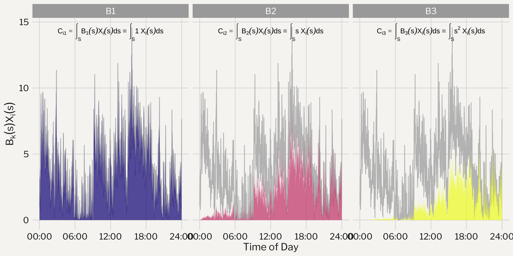

### Parametric estimation

$C_{ik}$: area under the product of basis function and $X_i(s)$

Cubic B-spline basis:

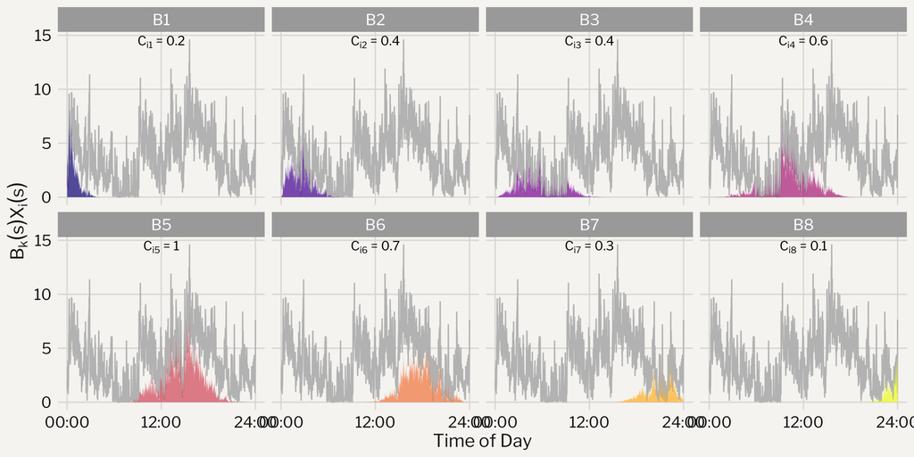

### Parametric estimation

Once we estimate $\boldsymbol{\beta}$, we can get $\hat{\beta}_1(s)$ by summing the basis coefficients and basis functions

Quadratic basis:

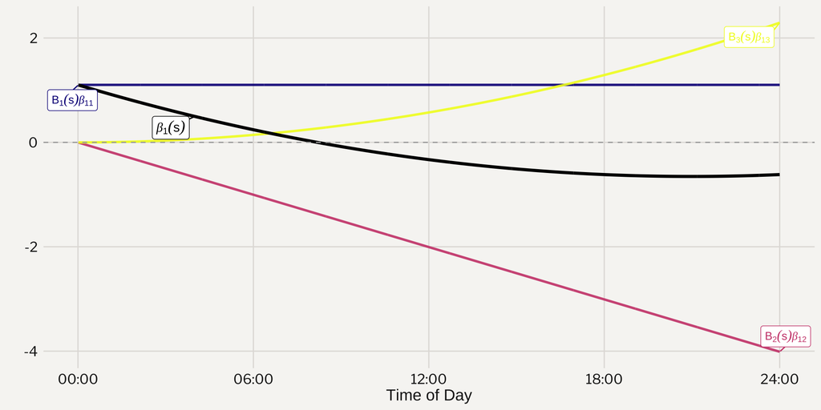

### Parametric estimation

Once we estimate $\boldsymbol{\beta}$, we can get $\hat{\beta}_1(s)$ by summing the basis coefficients and basis functions

Cubic basis:

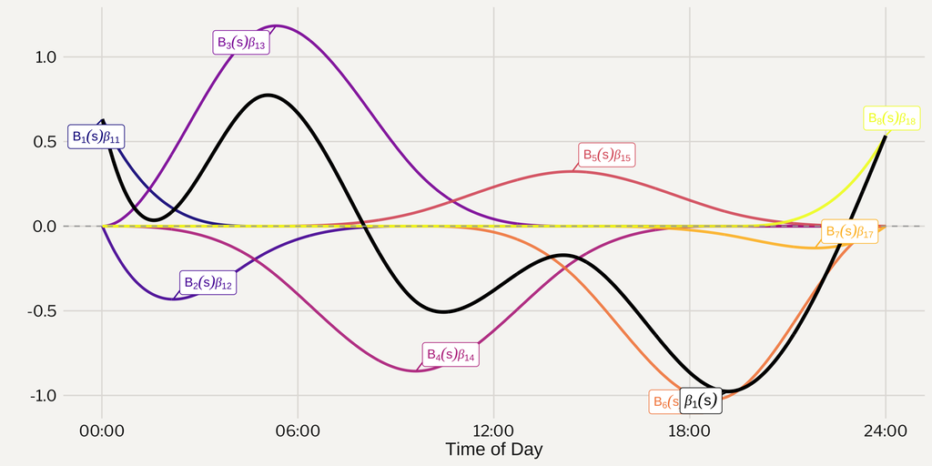

### So far

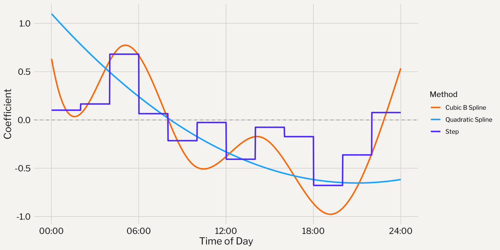

### So far

How do we pick the right degrees of freedom/wiggliness of our coefficient?

### So far

How do we pick the right degrees of freedom/wiggliness of our coefficient?

**In practice**: use rich spline basis and penalize based on the 2nd derivative (wiggliness)

### So far

How do we pick the right degrees of freedom/wiggliness of our coefficient?

**In practice**: use rich spline basis and penalize based on the 2nd derivative (wiggliness)

We have standard statistical software to fit these models!

```r
pfr_fit =
  pfr(bmi ~ lf(mims_mat, argvals = seq(1, 1440, 1),
               bs = "ps", k = 30) + age + gender,
              method = "REML", data = nh_df)
```

### So far

How do we pick the right degrees of freedom/wiggliness of our coefficient?

**In practice**: use rich spline basis and penalize based on the 2nd derivative (wiggliness)

We have standard statistical software to fit these models!

```r
pfr_fit =
  pfr(bmi ~ lf(mims_mat, argvals = seq(1, 1440, 1),
               bs = "ps", k = 30) + age + gender,
              method = "REML", data = nh_df)
```

## Conclusion

- We can use scalar on function regression to flexibly estimate relationship between functional predictor (PA) and outcome (BMI)
- What if outcome is function? (e.g., how does gender impact PA profile) Function on scalar regression
- And more!

## Resources

- [functionaldataanalysis.org](https://functionaldataanalysis.org/index.html)
- [FDA book link](https://www.taylorfrancis.com/books/mono/10.1201/9781003278726/functional-data-analysis-ciprian-crainiceanu-jeff-goldsmith-andrew-leroux-erjia-cui)
- Email me koffman@virginia.edu or stop by SDS 343